# 一、理论部分

## 聚类总结

最重要的是，必须注意如何报告聚类分析的结果。

给定一个多元数据集，寻找有意义的对象组，这样一个组中的对象彼此相似（或相关），并且与其他组中的对象不同。

### 聚类的应用

对于无监督学习的聚类分析，需要建立数值评价标准。

比如：3-means聚类

- 1、随机设3个中心点。初始值的选择会带来影响
- 2、按照距离分成三类聚类结果
- 3、重新计算k中心的位置（质点）
- 4、重新计算距离

**一些困难**

- 不同大小和密度的簇和非球形的簇的困难：倾向于把大的和稀疏的簇打散

### 层次聚类

- 如何定义集群间的差异性

方法如下：

```
- MIN(single-linkage)：容易受噪音值影响
- MAX(complete-linkage)：和k-means有点像，倾向于打散大的簇
```

- 为了选择集群，我们在树状图上划线（断点）

我们可以根据我们画的断点形成任意数量的集群，从而可以分成几类

- 缺点：
  - 无优化标准
  - 贪婪算法
  - 测量集群间距离的不同方法会产生非常不同的解决方案

# 二、实验部分

## 引入库

- 画图的：matplotlib.pyplot
- 聚类的：sklearn.cluster
- 数据集：sklearn.datasets

```python
import matplotlib.pyplot as plt
from sklearn.datasets import make_blobs
from sklearn.cluster import KMeans
```

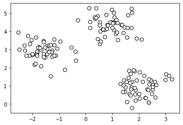

```python
# make_blobs：生成聚类的数据集
# n_samples：生成的样本点个数，n_features：样本特征数，centers：样本中心数
# cluster_std：聚类标准差，shuffle：是否打乱数据，random_state：随机种子
X, y = make_blobs(n_samples=150, n_features=2,centers=3, cluster_std=0.5,shuffle=True, random_state=0)

# 散点图
# c：点的颜色，marker：点的形状，edgecolor：点边缘的形状，s：点的大小
plt.scatter(X[:, 0], X[:, 1],c='white', marker='o',edgecolor='black', s=50)
plt.show()
```

```python
# 定义模型
# n_clusters：要形成的簇数，即k均值的k，init：初始化方式，tot：Frobenius 范数收敛的阈值
model = KMeans(n_clusters=3, init='random',n_init=10, max_iter=300, tol=1e-04, random_state=0)
# 训练加预测
y_pred = model.fit_predict(X)
y_pred
```

```
array([1, 0, 0, 0, 1, 0, 0, 1, 2, 0, 1, 2, 2, 0, 0, 2, 2, 1, 2, 1, 0, 1,
       0, 0, 2, 1, 1, 0, 2, 1, 2, 2, 2, 2, 0, 1, 1, 1, 0, 0, 2, 2, 0, 1,
       1, 1, 2, 0, 2, 0, 1, 0, 0, 1, 1, 2, 0, 1, 2, 0, 2, 2, 2, 2, 0, 2,
       0, 1, 0, 0, 0, 1, 1, 0, 1, 0, 0, 2, 2, 0, 1, 1, 0, 0, 1, 1, 1, 2,
       2, 1, 1, 0, 1, 0, 1, 0, 2, 2, 1, 1, 1, 1, 2, 1, 1, 0, 2, 0, 0, 0,
       2, 0, 1, 2, 0, 2, 0, 0, 2, 2, 0, 1, 0, 0, 1, 1, 2, 1, 2, 2, 2, 2,
       1, 2, 2, 2, 0, 2, 1, 2, 0, 0, 1, 1, 2, 2, 2, 2, 1, 1])
```

```python
#获取聚类标签
#实际上得到的跟y_pred一致的
label = model.labels_
label
```

```
array([1, 0, 0, 0, 1, 0, 0, 1, 2, 0, 1, 2, 2, 0, 0, 2, 2, 1, 2, 1, 0, 1,
       0, 0, 2, 1, 1, 0, 2, 1, 2, 2, 2, 2, 0, 1, 1, 1, 0, 0, 2, 2, 0, 1,
       1, 1, 2, 0, 2, 0, 1, 0, 0, 1, 1, 2, 0, 1, 2, 0, 2, 2, 2, 2, 0, 2,
       0, 1, 0, 0, 0, 1, 1, 0, 1, 0, 0, 2, 2, 0, 1, 1, 0, 0, 1, 1, 1, 2,
       2, 1, 1, 0, 1, 0, 1, 0, 2, 2, 1, 1, 1, 1, 2, 1, 1, 0, 2, 0, 0, 0,
       2, 0, 1, 2, 0, 2, 0, 0, 2, 2, 0, 1, 0, 0, 1, 1, 2, 1, 2, 2, 2, 2,
       1, 2, 2, 2, 0, 2, 1, 2, 0, 0, 1, 1, 2, 2, 2, 2, 1, 1])
```

```python
#中心点
center = model.cluster_centers_
center
```

```
array([[ 0.9329651 ,  4.35420712],
       [ 2.06521743,  0.96137409],
       [-1.5947298 ,  2.92236966]])
```

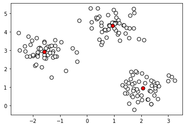

```python
#显示中心点
plt.scatter(X[:, 0], X[:, 1],c='white', marker='o',edgecolor='black', s=50)
plt.scatter(center[:, 0], center[:, 1],c='red', marker='o',edgecolor='black', s=50)
plt.show()
```

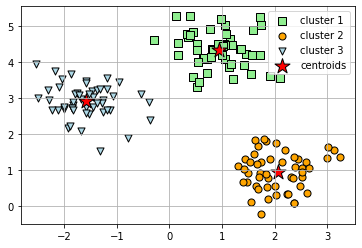

```python
# 画出预测的三个簇类
plt.scatter(
    X[y_pred == 0, 0], X[y_pred == 0, 1],
    s=50, c='lightgreen',
    marker='s', edgecolor='black',
    label='cluster 1'
)

plt.scatter(
    X[y_pred == 1, 0], X[y_pred == 1, 1],
    s=50, c='orange',
    marker='o', edgecolor='black',
    label='cluster 2'
)

plt.scatter(
    X[y_pred == 2, 0], X[y_pred == 2, 1],
    s=50, c='lightblue',
    marker='v', edgecolor='black',
    label='cluster 3'
)

# 画出聚类中心
plt.scatter(
    center[:, 0], center[:, 1],
    s=250, marker='*',
    c='red', edgecolor='black',
    label='centroids'
)
#设置图例，图例中标记点的个数=1
plt.legend(scatterpoints=1)
plt.grid()
plt.show()
```

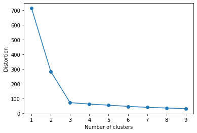

```python
#检查最佳的聚类（聚成几类）
# 计算inertia随着k变化的情况
distortions = []
for i in range(1, 10):
    model = KMeans(
        n_clusters=i, init='random',
        n_init=10, max_iter=300,
        tol=1e-04, random_state=0
    )
    model.fit(X)
    distortions.append(model.inertia_)
# 画图可以看出k越大inertia越小，追求k越大对应用无益处，应该找到一个折点
plt.plot(range(1, 10), distortions, marker='o')
plt.xlabel('Number of clusters')
plt.ylabel('Distortion')
plt.show()
```

## 有效性评价

因为是无监督学习，需要对模型进行有效性评价。常用的有Rand指数、轮廓系数……

### 使用轮廓系数进行有效性评价

轮廓系数出于-1至1之间，**越大**表示簇间相似度高而不同簇相似度低，也就是**聚类效果好**。

```python
from sklearn.metrics import silhouette_samples
lkxs = silhouette_samples(X,y_pred)
lkxs
```

```
array([0.75956181, 0.43233677, 0.7747553 , 0.72286402, 0.76729229,
       0.72280273, 0.69484791, 0.76101499, 0.77303671, 0.67320272,
       0.62375802, 0.40348569, 0.80092777, 0.73225118, 0.59884632,
       0.78954087, 0.75955598, 0.81572606, 0.79897477, 0.7936958 ,
       0.72221435, 0.76384238, 0.72671597, 0.73219594, 0.74183186,
       0.81463826, 0.76045682, 0.62065362, 0.57912988, 0.76929277,
       0.707709  , 0.8045906 , 0.7116979 , 0.78561661, 0.66997314,
       0.65285806, 0.68519649, 0.77015391, 0.72638012, 0.77905009,
       0.56028722, 0.70806176, 0.66201873, 0.77669657, 0.79206045,
       0.79499104, 0.67874476, 0.43073904, 0.72878986, 0.75911278,
       0.61479508, 0.68506268, 0.76602547, 0.80521304, 0.79571018,
       0.77872478, 0.63708395, 0.62515462, 0.58878683, 0.7767243 ,
       0.72889549, 0.40154174, 0.80287718, 0.78189854, 0.76687374,
       0.35466307, 0.79135592, 0.56967556, 0.37334246, 0.54630918,
       0.61918571, 0.70584253, 0.79635805, 0.61369253, 0.74071059,
       0.77509834, 0.7351302 , 0.72821908, 0.74135332, 0.78854416,
       0.80090725, 0.78961228, 0.51299076, 0.78719254, 0.71872541,
       0.6397918 , 0.78855017, 0.78917529, 0.7061704 , 0.76230562,
       0.79536861, 0.77859235, 0.70994165, 0.73209753, 0.80237062,
       0.50658208, 0.79045011, 0.74253797, 0.75363719, 0.65437536,
       0.77241946, 0.79373523, 0.64697003, 0.8139295 , 0.76899613,
       0.79172653, 0.79274343, 0.69700878, 0.78652188, 0.67972242,
       0.71886096, 0.75294696, 0.81081904, 0.74715119, 0.70247941,
       0.71866965, 0.79175454, 0.71721843, 0.75476664, 0.80440263,
       0.67305151, 0.77173621, 0.71490094, 0.56114424, 0.59401827,
       0.77385159, 0.77492826, 0.7884554 , 0.75189627, 0.78474349,
       0.77665128, 0.67446502, 0.7425489 , 0.78239431, 0.72242176,
       0.5257976 , 0.49846727, 0.800814  , 0.70372273, 0.79779972,
       0.77516089, 0.74387209, 0.70953106, 0.81307092, 0.53081359,
       0.75791717, 0.66709398, 0.73611334, 0.79529978, 0.73534283])
```

```python
#求均值
import numpy as np
means = np.mean(lkxs)
means
```

```
0.7143417887288687
```

可以看到均值是0.71，可以写一个循环计算聚类数从2到n-1的轮廓系数进行评价,能看出最佳聚类数

```python
def cluster_judge(n):
     model = KMeans(
        n_clusters=n, init='random',
        n_init=10, max_iter=300,
        tol=1e-04, random_state=0
    )
     model.fit(X)
     label = model.labels_
     lkxs = silhouette_samples(X,label)
     means = np.mean(lkxs)
     return means
```

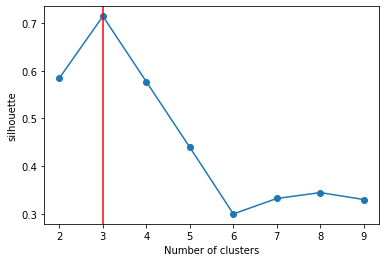

```python
y1 = []
for n in range(2,10):
    means = cluster_judge(n)
    y1.append(means)
# 画图
plt.plot(range(2, 10), y1, marker='o')
plt.xlabel('Number of clusters')
plt.ylabel('silhouette')
max_n = np.max(y1)
plt.axvline(x=3, ymin=0, ymax=1,c='red')
plt.show()
```

## 结论

最高的是聚类为3的点